# PatientProfiler Package

PerfettoLab

PatientProfiler is an R package that allows personalized analysis of an entire cohort and specific individuals. The main functions can be used sequentially or separately.

If we want to imagine a sequential way to use PatientProfiler, we can divide the pipeline into 5 main steps:

- **STEP 1** - Raw data harmonization/Access to harmonized CPTAC data & Input tables preparation
- **STEP 2** - Protein activity inference
- **STEP 3** - Generation of mechanistic models
- **STEP 4** - Network-based stratification (communities detection)
- **STEP 5** - Identification of biomarkers

[figure not shown]

## Install PatientProfiler

To install PatientProfiler execute the following commands in R. A crucial prerequisite for PatientProfiler is SignalingProfiler package.

```r
# Install SignalingProfiler
devtools::install_github('https://github.com/SaccoPerfettoLab/SignalingProfiler/')

# Install PatientProfiler
devtools::install_github('https://github.com/SaccoPerfettoLab/PatientProfiler/')
```

## Load necessary libraries

```r
library(PatientProfiler)
library(SignalingProfiler)
library(tidyverse)
```

## Set up Python PatientProfiler environment

PatientProfiler contains some functions executing Python source code. To correctly set up the Python PatientProfiler environment please execute the following code line the first time you use PatientProfiler:

```r
install_pp_py()
```

## PREPARE YOUR DATA

To use this R package, you need to have the right format for your input dataframes.

The input has to have specific columns, as described here:

- **Transcriptomics**:
  - **gene_name** - it indicates the names of genes/analytes
  - patients
- **Proteomics:**
  - **gene_name** - it indicates the names of genes/analytes
  - patients
- **Phosphoproteomics:**
  - **gene_name** - it indicates the names of genes/analytes
  - **Site** - *it reperesents the phosphorylation site with aminoacid and position (e.g. T161)*
  - **Peptide** - it contains the peptide sequence that includes the phosphorylated residue (optional)
  - patients

⚠️ Warning: The order of the columns is important and must strictly follow this structure. Incorrect column ordering may lead to errors during data processing.

## STEP 1a) RAW DATA HARMONIZATION

If the IDs of your samples start with a number, it is necessary to modify the IDs (e.g., with an ‘X’ before the number).

### *omics_update*

This function allows to update UniProt IDs, add the sequence window, imputing NAs and calculating the Z-score.

To **harmonize** your raw omics data, you need to:

1. Read your input dataframe(s);
2. Format the input in the way described in the “Prepare your data” section;
3. Choose the percent *threshold* of NAs to filter rows with >= threshold% of missing values;
4. Choose the **number of imputations** for proteomics and phosphoproteomics;
5. Choose **how to pull** dataframes derived from the imputation of proteomics and phosphoproteomics;
6. If you provide a phosphoproteomics dataframe, choose the *lenght of the sequence window*. You can insert **7** or **15;**
7. Choose the **imputation** method for proteomics and phosphoproteomics;
8. If you want to **normalize** with Z-score your data, insert *TRUE* for the zscore parameter, if not choose *FALSE;*
9. In the case you select *TRUE* for the Z-score calculation, you can also set the *method* (by “column” or by “row”) and the *metric* (“median” or “mean”).

This step for big dataframes requires many hours of working mainly due the imputation. For this tutorial we are using a smaller amount of patients to give you a general vision of results.

###Example of usage:

```r
phosphoproteomics_data <- read_tsv("./PatientProfiler_raw_input/Brca_phospho.tsv")

omics_update(
             df_tr = NULL,
             df_pr = NULL,
             df_ph = phosphoproteomics_data,
             threshold = 80,
             m= 5,
             collapse = "median",
             sw_len = 7,
             uniprot_idx = NULL,
             pep_col_name = "Peptide",
             imp_method = "norm",
             zscore = TRUE,
             zmethod = "column",
             metric = "median",
             output_dir = 'PatientProfiler_processed_input'
             )
```

The result of this step is each selected dataframe manipulated according to the chosen parameters. If, for example, the phosphoproteomics update was made, it will have the information regarding phosphosites updated with the *sequence_window* column and *Uniprot_ID* added, it will be imputed, and it will have a distribution based on whether or not Z-score should be calculated.

After this step, tables are ready for the *omics_preparation*.

The next steps of PatientProfiler include wrapper functions to our in-house developed [SignalingProfiler](https://www.nature.com/articles/s41540-024-00417-6) pipeline. As such, the harmonized data obtained with *omics_update* or *access_harmonized_CPTAC_data* should be transformed in SignalingProfiler-compliant format. To this aim, in **PatientProfiler**, we developed *omics_preparation* function.

### *omics_preparation*

For each uploaded omic type, a folder with a user-defined name will be created. Each folder will contain a file (data frame) for each patient, representing the needed omic input needed in SignalingProfiler-compliant format for the next steps.

### Example of usage:

```r
tr_updated <- read_tsv("./PatientProfiler_processed_input/Transcriptomics_updated.tsv")
pr_updated <- read_tsv("./PatientProfiler_processed_input/Proteomics_updated.tsv")
ph_updated <- read_tsv("./PatientProfiler_processed_input/Phosphoproteomics_updated.tsv")

omics_preparation(
              df_tr_updated = tr_updated,
              df_pr_updated = pr_updated,
              df_ph_updated = ph_updated,
              transc_dir_name = "Transc_patients",
              prot_dir_name = "Prot_patients",
              phospho_dir_name = "Phospho_patients"
              )
```

To perform the following steps, the SignalingProfiler tool is used: you can check out its tutorial [here](https://html-preview.github.io/?url=https://github.com/SaccoPerfettoLab/SignalingProfiler/blob/main/SignalingProfiler-2.0-tutorial/SignalingProfiler-2.0-tutorial.html) and the publication regarding it [here](https://www.nature.com/articles/s41540-024-00417-6).

## STEP 2) PROTEIN ACTIVITY INFERENCE

## *Infer signaling proteins activity at single patient level*

### *extract_protein_activity*

This function is a wrapper to *SignalingProfiler* first step functions, wherein protein activity modulation is inferred from multi-omics data combining footprint-based techniques with PhosphoScore algorithm.

To extract protein activity for a single patient, you need to upload transcriptomics, proteomics, or phosphoproteomics data (or all of them) and set the parameters as described in the information part of the function (see the description by typing “*?extract_protein_activity”* in your console).

The parameters are managed as a **list of default parameters** that you can change as you wish, either inside or outside the function call.

(**Note:** The `prot_df` parameter in tf_params and kin_params will only be used if a `prot_file` is specified, since the function automatically loads proteomics data only if `correct_proteomics` is `TRUE` and if it finds the specified file)

### Example of usage:

```r
tf_params <- list(reg_minsize = 5, collectri = TRUE)
kin_params <- list(reg_minsize = 5)

patient_id <- 'CPT000814'

extract_protein_activity(
                prot_file = paste0("Prot_patients/Prot_Patient_", patient_id, ".tsv"),
                trans_file = paste0("Transc_patients/Transc_Patient_", patient_id, ".tsv"),
                phospho_file = paste0("Phospho_patients/Phospho_Patient_", patient_id, ".tsv"),
                tf_params,
                kin_params,
                output_dir = "Activities"
                )
```

*Results output*

- `UNIPROT`: protein Uniprot ID.
- `gene_name`: name of the protein.
- `mf`: molecular functions.
- `final_score`: activity score.
- `method`: how final_score is calculated.

## *Infer signaling proteins activity at cohort level*

### *extract_cohort_activity*

To perform the protein activity inference step for all the patients of a cohort, this function loops on each omic file for each patient and infer protein activity using [*extract_protein_activity*]*.*

(**Note:** The `prot_df` parameter in tf_params and kin_params will only be used if a `prot_dir` is specified, since the function automatically loads proteomics data only if `correct_proteomics` is `TRUE` and if it finds files in the specified folder)

```r
tf_params <- list(reg_minsize = 5, collectri = TRUE)
kin_params <- list(exp_sign = TRUE)

extract_cohort_activity(
                        prot_dir = "Prot_patients/",
                        trans_dir = "Transc_patients/",
                        phospho_dir = "Phospho_patients/",
                        tf_params,
                        kin_params,
                        output_dir = "Activities"
                        )
```

*Results output*

The cohort final results will be saved as a set of .tsv files (1 file = 1 patient) inside the `output_dir` directory (default, ‘Activities’). Each patient-specific file (`Activity_patient_{patient_id}.tsv`) contains these columns:

- `UNIPROT`: protein Uniprot ID.
- `gene_name`: name of the protein.
- `mf`: molecular functions.
- `final_score`: activity score.
- `method`: how final_score is calculated.

## STEP 3) NETWORK GENERATION

## **Create a signaling network for a single patient**

In this step, PatientProfiler creates for each patient a causal network connecting mutated genes to a user-defined set of cellular functional traits (e.g., APOPTOSIS, PROLIFERATION).

Importantly, this step requires a **mutations file** where rows are patients and columns are genes, and each cell is the impact on protein function of the mutation.

To this aim, we implemented a wrapper to SignalingProfiler network creation step.

### *create_network*

This function sequentially calls five functions to:

1. Select a PKN derived from SIGNOR and PhosphoSitePlus (`get_PKN`);
2. Create a naive-network connecting mutations to inferred proteins (`create_naive_network`);
3. Optimize the naive network over protein activity (`optimize_network_with_carnival`);
4. Infer the activity of phenotypes from model proteins and connect them in a proteins-to-phenotypes network (`infer_and_link_phenotypes`);
5. Manipulate the proteins-to-phenotypes model for visualization and functional circuits creation (`format_patient_networks`).

Each step inside network creation requires a set of parameters, extensively described in the functions documentation (type *?initialize_net_default_params”* in your console. The following function is called internally and automatically set up the default parameters, as identified in SignalingProfiler benchmarking. However, the user can customize the parameters for each step modifying `PKN_options`, `naive_options`, `carnival_options`, `phenoscore_options`, `format_options` parameters list.

```r
output_dir <- 'Networks_output'
network_params <- initialize_net_default_params(output_dir)
```

### Example of usage:

```r
patient_id <- 'CPT000814'

# Read mutation file (starting nodes of the model)
mutations_df <- read_tsv('./PatientProfiler_raw_input/Brca_mutations.tsv', show_col_types = F)
sources <- mutations_df[mutations_df$Patient_ID == patient_id, ]

# Read activity file (intermediate nodes of the model)
activities <- read_tsv(paste0('./Activities/Activity_Patient_', patient_id, '.tsv'), show_col_types = F)

# Set the functional traits vector (final nodes of the model)
desired_phenotypes <- c('APOPTOSIS', 'PROLIFERATION')

# Read omics file
proteomics <- read_tsv(paste0('./Prot_patients/Prot_Patient_', patient_id, '.tsv'), , show_col_types = F)
transcriptomics <- read_tsv(paste0('./Transc_patients/Transc_Patient_', patient_id, '.tsv'), show_col_types = F)
phosphoproteomics <- read_tsv(paste0('./Phospho_patients/Phospho_Patient_', patient_id, '.tsv'), show_col_types = F)

# ProxPath proteins-to-phenotypes pre-processing
pheno_distances_table <- proxpath_preprocessing(proteomics = proteomics,
                                                phosphoproteomics = phosphoproteomics)

create_network(patient_id = patient_id,
              sources = sources,
              activities = activities,
              transcriptomics = transcriptomics,
              proteomics = proteomics,
              phosphoproteomics = phosphoproteomics,
              desired_phenotypes = desired_phenotypes,
              pheno_distances_table = pheno_distances_table,
              output_dir = 'Networks_output',
              save_all_files = FALSE,
              PKN_options = list(direct = FALSE),
              naive_options = list(layers = 2, max_length = c(1,4)),
              carnival_options = list(carnival_type = 'vanilla_one_shot'),
              phenoscore_options = list(), # keep default params
              format_options = list(optimize_on_phenotypes = FALSE,
                                    circuits_params = list(k = -1),
                                    vis_cytoscape = FALSE))
```

## *Create signaling networks at cohort level*

### *create_cohort_network*

This function loops on the folder of omics and activity data of a cohort of patients creating a network of each of the patients from mutations to desired phenotypes.

For the files generated for each patient, refer to *create_network* function documentation.

### Example of usage:

```r
create_cohort_networks(trans_dir = './Transc_patients/',
                      prot_dir = './Prot_patients/',
                      phospho_dir = './Phospho_patients/',
                      act_dir = './Activities/',
                      mut_file = './PatientProfiler_raw_input/Brca_mutations.tsv',
                      output_dir = './Networks_output/',
                      desired_phenotypes = c('APOPTOSIS', 'PROLIFERATION'),
                      pheno_distances_table = TRUE,
                      save_all_files = FALSE,
                      PKN_options = list(direct = FALSE),
                      naive_options = list(layers = 2, max_length = c(1,4)),
                      carnival_options = list(solver = 'cplex',
                                              carnival_type = 'vanilla_one_shot'),
                                              carnival_params = list(timelimit = 3600),
                      format_options = list(optimize_on_phenotypes = FALSE,
                                    circuits_params = list(k = -1),
                                    vis_cytoscape = FALSE)
                      )
```

## STEP 4) COMMUNITIES DETECTION

## *Generate communities from patient-specific mechanistic models*

### *generate_communities*

In this step, PatientProfiler extracts communities from the patient-specific mechanistic models generated in Step 3.

Importantly, this step requires a patient stratification file (patients_stratification.tsv), where each row represents a patient and the column indicates the subtype. You need to place this file in a designated directory (dir_path), which will be deleted after this step.

### Example of usage:

```r
generate_communities(dir_path = "./Communities/input_communities",
                     network_dir = "./Networks_output",
                     output_dir = "./Communities/output_communities")
```

You can visualize network communities using this function.

**Important:** Make sure the Cytoscape application is open before running this function.

```r
visualize_community("community_7")
```

*Results output*

The output_dir directory contains a subdirectory for each detected community. Each community directory includes:

A file for edges. A file for nodes. A file listing the patients belonging to the community.

## STEP 5) SIGNATURES IDENTIFICATIONS

## *Extract signaling-driven transcriptomics signature from communities*

### *extract_signatures*

To extract signaling-driven transcriptomic signatures you need the transcriptomics dataset obtained after Step 1 and the communities detected in Step 4.

### Example of usage:

```r
extract_signatures(base_path = "./Communities/output_communities/",
                   transcriptomics_file = "./PatientProfiler_processed_input/Transcriptomics_updated.tsv",
                   output_dir = "./",
                   padj_thres = 0.01,
                   mean_exp_clus_thres = 0,
                   max_val = 50)
```

*Results output*

The Signatures directory contains a dataframe for each signature with the genes list.

Furthermore, it’s possible to performs Kaplan-Meier survival analysis using the so obtained Signatures. To do this you need: a list of gene signatures (e.g., those extracted from Step 5), a transcriptomic expression matrix and optionally a clinical data table with patient survival information (serial_time, status)

### *test_signature_on_dataset*

### Example of usage:

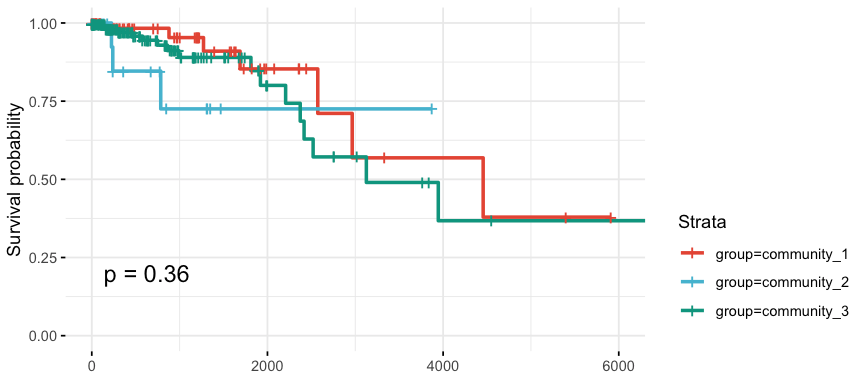

```r
# Define gene_signatures
gene_signatures <- list(
  community_1 = c(
    "ARHGDIB", "STARD3", "RAPGEFL1", "ERBB2", "FAM83E"
  ),
  community_2 = c(
    "CRABP1", "GABRP", "ELF5", "S100A1", "SNORD36A"
  ),
  community_3 = c(
    "TPRG1", "CHAD", "MALRD1", "BMPR1B", "CST9", "ADCY1", "RGS22", "DNAJC12", "LINC00993",
    "DNALI1", "LONRF2", "MIR6835"
  )
)



url <- "https://perfettolab.bio.uniroma1.it/PerfettoLabData/PatientProfiler/BrcaUseCase/Step5/TCGA/transcriptomics_TCGA_zscored.tsv"
file_path <- tempfile(fileext = ".tsv")
response <- httr::GET(url, httr::write_disk(file_path, overwrite = TRUE))
if (httr::http_status(response)$category == "Success") {
  t_omic_TCGA <- utils::read.delim(file_path, sep = "\t", header = TRUE, stringsAsFactors = FALSE)
} else {
  stop("Error:", httr::http_status(response)$message)
}
t_omic_TCGA <- stats::aggregate(t_omic_TCGA[, -1], by = list(Name = t_omic_TCGA$gene_name), mean)
transc <- t_omic_TCGA %>% dplyr::rename( gene_name = Name)
colnames(transc)[-1] <- gsub("\\.", "-", colnames(transc)[-1])



clinical <- read_tsv("clinical_TCGA_example.tsv")



test_results <- test_signature_on_dataset(
  gene_signatures = gene_signatures,
  transcriptomic_data = transc,
  clinical_data = clinical,
  NES_filter = TRUE,
  pval_cutoff = 0.01,
  palette = 'npg'
)

test_results$plot
```